# Index Return Prediction

1. Load Data
2. Exploratory Analysis and Data Preprocessing  
   2.1. Data Understanding  
   2.2. Data Cleaning and Verifying
3. Data Preparation  
   3.1. Classification Model - Data Preparation  
   3.2. Regression Model - Data Preparation
4. Classification Task  
   4.1. Model Selection  
   4.1.1. Logistic Regression  
   4.1.2. Random Forest  
   4.1.3. Support Vector Machine (SVM)  
   4.1.4. K-Nearest Neighbor (KNN)  
   4.1.5. Naive Bayes  
   4.2. Evaluation
5. Regression Task  
   5.1. Model Selection  
   5.1.1. Linear Regression  
   5.1.2. Ridge Regression  
   5.1.3. Lasso Regression  
   5.1.4. Support Vector Regression (SVR)  
   5.2. Evaluation
6. Reference
7. AI Tool Chat History

# 1. Load Data

```python
# Import Library
import pandas as pd

# Show All Column
pd.set_option('display.max_columns', None)
```

## Main Data

```python
company_info = pd.read_csv(company_info_path).convert_dtypes()
```

```python
index = pd.read_csv(index_path).convert_dtypes()
```

```python
stock_data = pd.read_csv(stock_data_path).convert_dtypes()
```

## Optional Data

```python
fed_funds = pd.read_csv(fed_funds_path).convert_dtypes()
```

```python
fed_inflation = pd.read_csv(fed_inflation_path).convert_dtypes()
```

```python
fed_unemployment = pd.read_csv(fed_unemployment_path).convert_dtypes()
```

```python
us_10year = pd.read_csv(us_10year_path).convert_dtypes()
```

```python
us_5year = pd.read_csv(us_5year_path).convert_dtypes()
```

```python
vix_index = pd.read_csv(vix_index_path).convert_dtypes()
```

## Target Data

```python
training_targets = pd.read_csv(training_targets_path).convert_dtypes()
testing_targets = pd.read_csv(testing_targets_path).convert_dtypes()
```

# 2. Data Wrangling

Because optional data only consists of simple data with little volume of data, the exploratory analysis and data preprocessing is focused on main datasets (`company_info`, `index`, and `stock_data`)

##### 2.1 Data Understanding

```python
# Statistical Summary
def describe_new(df):
    df1 = df.describe()
    df1.loc["range"] = df1.loc['max'] - df1.loc['min']
    return df1
```

**Stock Data**

```python
stock_data.info()
stock_data.head()
```

```
<class 'pandas.core.frame.DataFrame'>
RangeIndex: 25618 entries, 0 to 25617
Data columns (total 18 columns):
 #   Column                 Non-Null Count  Dtype
---  ------                 --------------  -----
 0   stock_id               25618 non-null  string
 1   month_id               25618 non-null  string
 2   month_start_open_usd   25618 non-null  Float64
 3   month_end_close_usd    25618 non-null  Float64
 4   month_high_usd         25618 non-null  Float64
 5   month_low_usd          25618 non-null  Float64
 6   monthly_volume         25618 non-null  Int64
 7   intramonth_return      25618 non-null  Float64
 8   return_1m              25597 non-null  Float64
 9   return_3m              25555 non-null  Float64
 10  return_6m              25483 non-null  Float64
 11  intramonth_volatility  25616 non-null  Float64
 12  volatility_3m          25555 non-null  Float64
 13  volatility_6m          25483 non-null  Float64
 14  trading_days           25618 non-null  Int64
 15  avg_volume_3m          25576 non-null  Int64
 16  volume_ratio           25576 non-null  Float64
 17  price_range_ratio      25618 non-null  Float64
dtypes: Float64(13), Int64(3), string(2)
memory usage: 3.9 MB
```

|  | stock_id | month_id | month_start_open_usd | month_end_close_usd | month_high_usd | month_low_usd | monthly_volume | intramonth_return | return_1m | return_3m | return_6m | intramonth_volatility | volatility_3m | volatility_6m | trading_days | avg_volume_3m | volume_ratio | price_range_ratio |
| --- | --- | --- | --- | --- | --- | --- | --- | --- | --- | --- | --- | --- | --- | --- | --- | --- | --- | --- |
| 0 | US001 | 2020_01 | 120.192 | 107.326 | 123.486 | 107.035 | 84539259 | -0.107045 | -0.100669 | -0.030041 | -0.075676 | 0.253304 | 0.278396 | 0.201608 | 21 | 3182487 | 1.207 | 0.136875 |
| 1 | US001 | 2020_02 | 108.252 | 101.868 | 111.641 | 99.636 | 91313882 | -0.058974 | -0.050854 | -0.112968 | -0.060752 | 0.259208 | 0.245523 | 0.192782 | 19 | 3686371 | 1.126 | 0.110905 |
| 2 | US001 | 2020_03 | 103.301 | 93.178 | 105.622 | 77.841 | 177930833 | -0.097995 | -0.085299 | -0.219214 | -0.154874 | 0.892709 | 0.088364 | 0.213051 | 22 | 5360363 | 1.509 | 0.268931 |
| 3 | US001 | 2020_04 | 90.1 | 103.697 | 111.314 | 89.424 | 98448862 | 0.15091 | 0.112885 | -0.03381 | -0.062835 | 0.408352 | 0.366808 | 0.291241 | 21 | 5571115 | 0.803 | 0.242954 |
| 4 | US001 | 2020_05 | 101.909 | 107.841 | 110.206 | 89.499 | 103380207 | 0.058209 | 0.039966 | 0.058641 | -0.060951 | 0.419368 | 0.347233 | 0.29204 | 20 | 5753938 | 0.817 | 0.203186 |

```python
describe_new(stock_data)
```

|  | month_start_open_usd | month_end_close_usd | month_high_usd | month_low_usd | monthly_volume | intramonth_return | return_1m | return_3m | return_6m | intramonth_volatility | volatility_3m | volatility_6m | trading_days | avg_volume_3m | volume_ratio | price_range_ratio |
| --- | --- | --- | --- | --- | --- | --- | --- | --- | --- | --- | --- | --- | --- | --- | --- | --- |
| count | 25618.0 | 25618.0 | 25618.0 | 25618.0 | 25618.0 | 25618.0 | 25597.0 | 25555.0 | 25483.0 | 25616.0 | 25555.0 | 25483.0 | 25618.0 | 25576.0 | 25576.0 | 25618.0 |
| mean | 133.718601 | 134.509803 | 144.473964 | 123.620124 | 124773628.124014 | 0.012421 | 0.01474 | 0.042243 | 0.093739 | 0.384489 | 0.337133 | 0.356375 | 20.944414 | 5641095.169143 | 1.005413 | 0.17559 |
| std | 245.900862 | 248.289855 | 263.700953 | 229.767331 | 472180569.463592 | 0.126536 | 0.12558 | 0.224537 | 0.397024 | 0.253038 | 0.280432 | 0.240778 | 1.194822 | 20943487.832493 | 0.209451 | 0.126633 |
| min | 0.7 | 0.71 | 0.997 | 0.463 | 1500.0 | -0.836003 | -0.832263 | -0.891459 | -0.878101 | 0.037019 | 0.001361 | 0.020767 | 0.0 | 144.0 | 0.046 | 0.010922 |
| 25% | 40.7695 | 40.839 | 44.31925 | 37.0655 | 20263175.0 | -0.054867 | -0.053 | -0.073179 | -0.093493 | 0.230496 | 0.174882 | 0.220319 | 20.0 | 943896.0 | 0.87 | 0.10196 |
| 50% | 78.925 | 79.129 | 85.5015 | 72.6075 | 44139100.0 | 0.006757 | 0.010027 | 0.026508 | 0.05457 | 0.312991 | 0.276629 | 0.300236 | 21.0 | 2040365.5 | 0.984 | 0.142549 |
| 75% | 156.38375 | 157.484 | 168.71875 | 144.1025 | 104673000.0 | 0.070576 | 0.073907 | 0.137254 | 0.220102 | 0.450122 | 0.420836 | 0.420214 | 22.0 | 4773016.25 | 1.111 | 0.207368 |
| max | 5870.0 | 6350.62 | 6386.62 | 5528.09 | 15856552000.0 | 3.257143 | 3.197183 | 6.892996 | 19.942211 | 3.458247 | 7.123194 | 4.90475 | 23.0 | 600017152.0 | 2.602 | 3.457143 |
| range | 5869.3 | 6349.91 | 6385.623 | 5527.627 | 15856550500.0 | 4.093146 | 4.029446 | 7.784455 | 20.820312 | 3.421228 | 7.121833 | 4.883983 | 23.0 | 600017008.0 | 2.556 | 3.446221 |

```python
stock_data['monthly_volume'].value_counts()
```

```
monthly_volume
25373400     3
7504100      3
24301800     2
18939900     2
11338600     2
            ..
209151700    1
269148500    1
237384000    1
313669000    1
10748300     1
Name: count, Length: 25374, dtype: Int64
```

Plotting `stock_data` with candlestick using `mpl_finance`

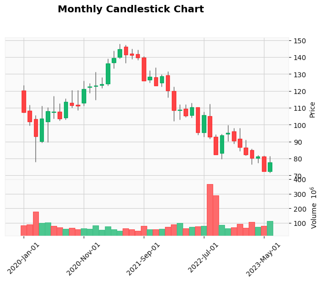

| month_id | Open | Close | High | Low | Volume | intramonth_return | return_1m | return_3m | return_6m | intramonth_volatility | volatility_3m | volatility_6m | trading_days | avg_volume_3m | volume_ratio | price_range_ratio |
| --- | --- | --- | --- | --- | --- | --- | --- | --- | --- | --- | --- | --- | --- | --- | --- | --- |
| 2020-01-01 | 120.192 | 107.326 | 123.486 | 107.035 | 84539259 | -0.107045 | -0.100669 | -0.030041 | -0.075676 | 0.253304 | 0.278396 | 0.201608 | 21 | 3182487 | 1.207 | 0.136875 |
| 2020-02-01 | 108.252 | 101.868 | 111.641 | 99.636 | 91313882 | -0.058974 | -0.050854 | -0.112968 | -0.060752 | 0.259208 | 0.245523 | 0.192782 | 19 | 3686371 | 1.126 | 0.110905 |
| 2020-03-01 | 103.301 | 93.178 | 105.622 | 77.841 | 177930833 | -0.097995 | -0.085299 | -0.219214 | -0.154874 | 0.892709 | 0.088364 | 0.213051 | 22 | 5360363 | 1.509 | 0.268931 |
| 2020-04-01 | 90.100 | 103.697 | 111.314 | 89.424 | 98448862 | 0.15091 | 0.112885 | -0.03381 | -0.062835 | 0.408352 | 0.366808 | 0.291241 | 21 | 5571115 | 0.803 | 0.242954 |
| 2020-05-01 | 101.909 | 107.841 | 110.206 | 89.499 | 103380207 | 0.058209 | 0.039966 | 0.058641 | -0.060951 | 0.419368 | 0.347233 | 0.29204 | 20 | 5753938 | 0.817 | 0.203186 |

```python
import mplfinance as mpf

# Deep copy the dataset for visualisation (not to tamper with the original dataset)
df = stock_data.copy(deep=True)

df['month_id'] = pd.to_datetime(df['month_id'], format='%Y_%m')

df = df.set_index('month_id')

# Rename to OHLC expected names
ohlc = df.rename(columns={
    'month_start_open_usd': 'Open',
    'month_end_close_usd': 'Close',
    'month_high_usd': 'High',
    'month_low_usd': 'Low',
    'monthly_volume': 'Volume'
})

# Filter one stock (e.g., AAPL)
stock_df = ohlc[ohlc['stock_id'] == 'US001'].drop(columns=['stock_id'])

# Convert Datatypes
stock_df['Volume'] = stock_df['Volume'].fillna(0).astype(int)  # or int
stock_df['Open']   = stock_df['Open'].fillna(0).astype(float)
stock_df['High']   = stock_df['High'].fillna(0).astype(float)
stock_df['Low']    = stock_df['Low'].fillna(0).astype(float)
stock_df['Close']  = stock_df['Close'].fillna(0).astype(float)

# Plot candlestick chart
mpf.plot(
    stock_df,
    type='candle',
    volume=True,
    style='yahoo',
    title='Monthly Candlestick Chart'
)
stock_df.head()
```

Findings:

- `stock_data` has 25618 records with 18 columns, mostly consists of numerical data (int64 and float64) which is logical because its mainly of price of the stock data and its other characteristics (return, volatility, etc).
- To verify the data, particularly the identifier data (`stock_id` and `month_id`) which are object, verifying by regular expression is required
- Transform numerical data by normalization, standardization, dicretisation, and or binning/bucketing are needed to appropriately fit the classification and regression model:
  - Large range, high std: `month_start_open_usd`, `month_end_close_usd`, `month_high_usd`, and `month_low_usd`, -> Standarization
  - Extreme Range: `monthly_volume` -> Normalization (+ standarization)
  - Relatively Centered (small value and std): `intramonth_return`, `return_1m`, `return_3m`, `return_6m`, `intramonth_volatility`, `volatility_3m`, `volatility_6m` -> Binning for Classification

## Company Info

```python
company_info.info()
company_info.head()
company_info.tail()
```

```
<class 'pandas.core.frame.DataFrame'>
RangeIndex: 616 entries, 0 to 615
Data columns (total 11 columns):
 #   Column                 Non-Null Count  Dtype
---  ------                 --------------  -----
 0   stock_id               616 non-null    string
 1   sector                 616 non-null    string
 2   business_model         616 non-null    string
 3   geographic_focus       616 non-null    string
 4   business_maturity      616 non-null    string
 5   competitive_position   616 non-null    string
 6   market_cap_category    616 non-null    string
 7   revenue_tier           616 non-null    string
 8   profitability_profile  616 non-null    string
 9   asset_intensity        616 non-null    string
 10  financial_strength     616 non-null    string
dtypes: string(11)
memory usage: 53.1 KB
```

|  | stock_id | sector | business_model | geographic_focus | business_maturity | competitive_position | market_cap_category | revenue_tier | profitability_profile | asset_intensity | financial_strength |
| --- | --- | --- | --- | --- | --- | --- | --- | --- | --- | --- | --- |
| 611 | US646 | Finance | B2C | Domestic | Cyclical | Niche_Specialist | Mid | Tier_2 | Standard | Moderate | Developing |
| 612 | US647 | Finance | B2C | International | Mature | Strong_Player | Mid | Tier_2 | Standard | Moderate | Developing |
| 613 | US648 | Finance | B2C | Domestic | Growth | Strong_Player | Mid | Tier_2 | Standard | Moderate | Developing |
| 614 | US649 | Finance | B2C | International | Mature | Strong_Player | Mid | Tier_2 | Low_Margin | Moderate | Developing |
| 615 | US650 | Finance | B2C | Domestic | Mature | Strong_Player | Mid | Tier_2 | Low_Margin | Asset_Light | Stable |

```python
company_info.groupby('sector').count()
```

| sector | stock_id | business_model | geographic_focus | business_maturity | competitive_position | market_cap_category | revenue_tier | profitability_profile | asset_intensity | financial_strength |
| --- | --- | --- | --- | --- | --- | --- | --- | --- | --- | --- |
| Communication | 28 | 28 | 28 | 28 | 28 | 28 | 28 | 28 | 28 | 28 |
| Consumer_Discretionary | 75 | 75 | 75 | 75 | 75 | 75 | 75 | 75 | 75 | 75 |
| Consumer_Staples | 40 | 40 | 40 | 40 | 40 | 40 | 40 | 40 | 40 | 40 |
| Energy | 29 | 29 | 29 | 29 | 29 | 29 | 29 | 29 | 29 | 29 |
| Finance | 87 | 87 | 87 | 87 | 87 | 87 | 87 | 87 | 87 | 87 |
| Healthcare | 83 | 83 | 83 | 83 | 83 | 83 | 83 | 83 | 83 | 83 |
| Industrials | 86 | 86 | 86 | 86 | 86 | 86 | 86 | 86 | 86 | 86 |
| Materials | 25 | 25 | 25 | 25 | 25 | 25 | 25 | 25 | 25 | 25 |
| Other | 1 | 1 | 1 | 1 | 1 | 1 | 1 | 1 | 1 | 1 |
| Real_Estate | 31 | 31 | 31 | 31 | 31 | 31 | 31 | 31 | 31 | 31 |
| Technology | 100 | 100 | 100 | 100 | 100 | 100 | 100 | 100 | 100 | 100 |
| Utilities | 31 | 31 | 31 | 31 | 31 | 31 | 31 | 31 | 31 | 31 |

Because all the columns and records in `company_info` dataset are object, it only needs data verifying and exploration:

- Regular Expression on identifier `stock_id` and uniform format of `revenue_tier`
- Exploration to identify unusual record

**Index**

```python
index.info()
index.head()
```

```
<class 'pandas.core.frame.DataFrame'>
RangeIndex: 42 entries, 0 to 41
Data columns (total 3 columns):
 #   Column        Non-Null Count  Dtype
---  ------        --------------  -----
 0   month_id      42 non-null     string
 1   index_return  42 non-null     Float64
 2   index_value   42 non-null     Float64
dtypes: Float64(2), string(1)
memory usage: 1.2 KB
```

|  | month_id | index_return | index_value |
| --- | --- | --- | --- |
| 0 | 2020_01 | -0.006452 | 99.354842 |
| 1 | 2020_02 | -0.053054 | 94.083684 |
| 2 | 2020_03 | -0.111379 | 83.604709 |
| 3 | 2020_04 | 0.141313 | 95.419099 |
| 4 | 2020_05 | 0.071232 | 102.215965 |

Because `index` data only consists of formatted and ordered data (based on `month_id`) with small amount of data:

- Check for missing and duplicated data are required
- Check consistency, particularly on `month_id`

## Optional Data

```python
fed_funds.info()
fed_funds.head()
```

```
<class 'pandas.core.frame.DataFrame'>
RangeIndex: 42 entries, 0 to 41
Data columns (total 2 columns):
 #   Column    Non-Null Count  Dtype
---  ------    --------------  -----
 0   month_id  42 non-null     object
 1   fed_rate  42 non-null     float64
dtypes: float64(1), object(1)
memory usage: 804.0+ bytes
```

|  | month_id | fed_rate |
| --- | --- | --- |
| 0 | 2020_01 | 1.55 |
| 1 | 2020_02 | 1.58 |
| 2 | 2020_03 | 0.65 |
| 3 | 2020_04 | 0.05 |
| 4 | 2020_05 | 0.05 |

```python
fed_inflation.info()
fed_inflation.head()
```

```
<class 'pandas.core.frame.DataFrame'>
RangeIndex: 42 entries, 0 to 41
Data columns (total 2 columns):
 #   Column          Non-Null Count  Dtype
---  ------          --------------  -----
 0   month_id        42 non-null     object
 1   inflation_rate  42 non-null     float64
dtypes: float64(1), object(1)
memory usage: 804.0+ bytes
```

|  | month_id | inflation_rate |
| --- | --- | --- |
| 0 | 2020_01 | 2.599768 |
| 1 | 2020_02 | 2.341317 |
| 2 | 2020_03 | 1.494040 |
| 3 | 2020_04 | 0.313047 |
| 4 | 2020_05 | 0.198201 |

```python
fed_unemployment.info()
fed_unemployment.head()
```

```
<class 'pandas.core.frame.DataFrame'>
RangeIndex: 42 entries, 0 to 41
Data columns (total 2 columns):
 #   Column             Non-Null Count  Dtype
---  ------             --------------  -----
 0   month_id           42 non-null     object
 1   unemployment_rate  42 non-null     float64
dtypes: float64(1), object(1)
memory usage: 804.0+ bytes
```

|  | month_id | unemployment_rate |
| --- | --- | --- |
| 0 | 2020_01 | 3.6 |
| 1 | 2020_02 | 3.5 |
| 2 | 2020_03 | 4.4 |
| 3 | 2020_04 | 14.8 |
| 4 | 2020_05 | 13.2 |

```python
us_10year.info()
us_10year.head()
```

```
<class 'pandas.core.frame.DataFrame'>
RangeIndex: 42 entries, 0 to 41
Data columns (total 2 columns):
 #   Column        Non-Null Count  Dtype
---  ------        --------------  -----
 0   month_id      42 non-null     object
 1   10y_treasury  42 non-null     float64
dtypes: float64(1), object(1)
memory usage: 804.0+ bytes
```

|  | month_id | 10y_treasury |
| --- | --- | --- |
| 0 | 2020_01 | 1.52 |
| 1 | 2020_02 | 1.13 |
| 2 | 2020_03 | 0.70 |
| 3 | 2020_04 | 0.62 |
| 4 | 2020_05 | 0.65 |

```python
us_5year.info()
us_5year.head()
```

```
<class 'pandas.core.frame.DataFrame'>
RangeIndex: 42 entries, 0 to 41
Data columns (total 2 columns):
 #   Column       Non-Null Count  Dtype
---  ------       --------------  -----
 0   month_id     42 non-null     object
 1   5y_treasury  42 non-null     float64
dtypes: float64(1), object(1)
memory usage: 804.0+ bytes
```

|  | month_id | 5y_treasury |
| --- | --- | --- |
| 0 | 2020_01 | 1.33 |
| 1 | 2020_02 | 0.91 |
| 2 | 2020_03 | 0.38 |
| 3 | 2020_04 | 0.34 |
| 4 | 2020_05 | 0.30 |

```python
vix_index.info()
vix_index.head()
```

```
<class 'pandas.core.frame.DataFrame'>
RangeIndex: 42 entries, 0 to 41
Data columns (total 2 columns):
 #   Column    Non-Null Count  Dtype
---  ------    --------------  -----
 0   month_id  42 non-null     object
 1   vix       42 non-null     float64
dtypes: float64(1), object(1)
memory usage: 804.0+ bytes
```

|  | month_id | vix |
| --- | --- | --- |
| 0 | 2020_01 | 13.94 |
| 1 | 2020_02 | 19.63 |
| 2 | 2020_03 | 57.74 |
| 3 | 2020_04 | 41.45 |
| 4 | 2020_05 | 30.90 |

All the optional dataset have the similar structures (records and columns), similar to `index`, its consists of formatted and ordered data (based on `month_id`) with small amount of data:

- Check for missing and duplicated data are required
- Check consistency, particularly on `month_id`

## 2.2. Data Cleaning & Verification

###### ReGex Verification

```python
# Import Library
import re

# Define Verifying Function
def check_regex(df, data):
    if data == "stock_id":
        # Pattern: US + 3-digit (001 - 650)
        pattern = r"^US(00[1-9]|0[1-9][0-9]|[1-5][0-9]{2}|6[0-4][0-9]|650)$"
        return df["stock_id"].astype(str).str.match(pattern)

    elif data == "month_id":
        # Pattern: YYYY-MM where MM = 01–12
        pattern = r"^[0-9]{4}_(0[1-9]|1[0-2])$"
        return df["month_id"].astype(str).str.match(pattern)

    else:
        raise ValueError("Unknown data type: choose 'stock_id' or 'month_id'")
```

**`stock_id`**

```python
check_regex(stock_data, "stock_id").value_counts()
```

| stock_id | count |
| --- | --- |
| True | 25618 |

**dtype:** int64

```python
stock_data.tail()
```

|  | stock_id | month_id | month_start_open_usd | month_end_close_usd | month_high_usd | month_low_usd | monthly_volume | intramonth_return | return_1m | return_3m | return_6m | intramonth_volatility | volatility_3m | volatility_6m | trading_days | avg_volume_3m | volume_ratio | price_range_ratio |
| --- | --- | --- | --- | --- | --- | --- | --- | --- | --- | --- | --- | --- | --- | --- | --- | --- | --- | --- |
| 25613 | US650 | 2023_02 | 32.249 | 32.395 | 34.202 | 32.102 | 6730100 | 0.004527 | -0.003958 | 0.001408 | 0.110988 | 0.238944 | 0.183777 | 0.483301 | 19 | 380447.0 | 0.804 | 0.065131 |
| 25614 | US650 | 2023_03 | 32.256 | 27.823 | 32.949 | 26.049 | 33499300 | -0.137432 | -0.141146 | -0.095845 | 0.018786 | 0.483441 | 0.351460 | 0.527833 | 23 | 767948.0 | 1.983 | 0.213917 |
| 25615 | US650 | 2023_04 | 27.869 | 25.901 | 28.266 | 25.208 | 15968600 | -0.070616 | -0.069057 | -0.203621 | -0.265272 | 0.251317 | 0.237719 | 0.236223 | 19 | 851485.0 | 0.852 | 0.109712 |
| 25616 | US650 | 2023_05 | 25.837 | 24.250 | 26.515 | 22.077 | 14985600 | -0.061424 | -0.063757 | -0.251432 | -0.250379 | 0.425258 | 0.149760 | 0.231152 | 22 | 976568.0 | 0.698 | 0.171788 |
| 25617 | US650 | 2023_06 | 24.399 | 24.725 | 28.389 | 24.007 | 10748300 | 0.013361 | 0.019608 | -0.111321 | -0.196496 | 0.449686 | 0.172274 | 0.248056 | 21 | 631856.0 | 0.773 | 0.179595 |

**NOTE**: It said that this problem is solved by Lecturer Team, but I already use the revised one. Will check later.

Lance: `company_data` has US650, I think row numbers in the dataset doesn't directly correspond to the `stock_id`

```python
check_regex(company_info, "stock_id").value_counts()
```

| stock_id | count |
| --- | --- |
| True | 616 |

**dtype:** int64

**`month_id`**

```python
check_regex(stock_data, "month_id").value_counts()
```

| month_id | count |
| --- | --- |
| True | 25618 |

**dtype:** int64

```python
check_regex(index, "month_id").value_counts()
```

| month_id | count |
| --- | --- |
| True | 42 |

**dtype:** int64

```python
check_regex(fed_funds, "month_id").value_counts()
```

| month_id | count |
| --- | --- |
| True | 42 |

**dtype:** int64

```python
check_regex(fed_inflation, "month_id").value_counts()
```

| month_id | count |
| --- | --- |
| True | 42 |

**dtype:** int64

```python
check_regex(fed_unemployment, "month_id").value_counts()
```

| month_id | count |
| --- | --- |
| True | 42 |

**dtype:** int64

```python
check_regex(us_10year, "month_id").value_counts()
```

| month_id | count |
| --- | --- |
| True | 42 |

**dtype:** int64

```python
check_regex(us_5year, "month_id").value_counts()
```

| month_id | count |
| --- | --- |
| True | 42 |

**dtype:** int64

```python
check_regex(vix_index, "month_id").value_counts()
```

| month_id | count |
| --- | --- |
| True | 42 |

**dtype:** int64

###### Data Cleaning

**Missing Values**

```python
stock_data.isna().sum()
```

|  | 0 |
| --- | --- |
| stock_id | 0 |
| month_id | 0 |
| month_start_open_usd | 0 |
| month_end_close_usd | 0 |
| month_high_usd | 0 |
| month_low_usd | 0 |
| monthly_volume | 0 |
| intramonth_return | 0 |
| return_1m | 21 |
| return_3m | 63 |
| return_6m | 135 |
| intramonth_volatility | 2 |
| volatility_3m | 63 |
| volatility_6m | 135 |
| trading_days | 0 |
| avg_volume_3m | 42 |
| volume_ratio | 42 |
| price_range_ratio | 0 |

**dtype:** int64

```python
company_info.isna().sum()
```

|  | 0 |
| --- | --- |
| stock_id | 0 |
| sector | 0 |
| business_model | 0 |
| geographic_focus | 0 |
| business_maturity | 0 |
| competitive_position | 0 |
| market_cap_category | 0 |
| revenue_tier | 0 |
| profitability_profile | 0 |
| asset_intensity | 0 |
| financial_strength | 0 |

**dtype:** int64

```python
index.isna().sum()
```

|  | 0 |
| --- | --- |
| month_id | 0 |
| index_return | 0 |
| index_value | 0 |

**dtype:** int64

```python
fed_funds.isna().sum()
```

|  | 0 |
| --- | --- |
| month_id | 0 |
| fed_rate | 0 |

**dtype:** int64

```python
fed_inflation.isna().sum()
```

|  | 0 |
| --- | --- |
| month_id | 0 |
| inflation_rate | 0 |

**dtype:** int64

```python
fed_unemployment.isna().sum()
```

|  | 0 |
| --- | --- |
| month_id | 0 |
| unemployment_rate | 0 |

**dtype:** int64

```python
us_10year.isna().sum()
```

|  | 0 |
| --- | --- |
| month_id | 0 |
| 10y_treasury | 0 |

**dtype:** int64

```python
us_5year.isna().sum()
```

|  | 0 |
| --- | --- |
| month_id | 0 |
| 5y_treasury | 0 |

**dtype:** int64

```python
vix_index.isna().sum()
```

|  | 0 |
| --- | --- |
| month_id | 0 |
| vix | 0 |

**dtype:** int64

There are several data with missing values in `stock_data`:

- `return_1m`
- `return_3m`
- `return_6m`
- `intramonth_volatility`
- `volatility_3m`
- `volatility_6m`
- `avg_volume_3m`
- `volume_ratio`

**NOTE**: Need to check the contextual of missing values based on the data dictionary or pattern

```python
stock_data.columns[stock_data.isna().any()]
```

```
Index(['return_1m', 'return_3m', 'return_6m', 'intramonth_volatility',
       'volatility_3m', 'volatility_6m', 'avg_volume_3m', 'volume_ratio'],
      dtype='object')
```

```python
# Detecting the percentage of missing values in the column
null_percent = stock_data.isna().sum() / stock_data.shape[0] * 100
null_percent[null_percent > 0]
```

|  | 0 |
| --- | --- |
| return_1m | 0.081974 |
| return_3m | 0.245921 |
| return_6m | 0.526973 |
| intramonth_volatility | 0.007807 |
| volatility_3m | 0.245921 |
| volatility_6m | 0.526973 |
| avg_volume_3m | 0.163947 |
| volume_ratio | 0.163947 |

**dtype:** float64

**NOTE** Based on the calculation, it safe to drop the records with missing value (<1%)

**Duplicate Data**

```python
stock_data.duplicated().value_counts()
```

|  | count |
| --- | --- |
| False | 25618 |

**dtype:** int64

```python
company_info.duplicated().value_counts()
```

|  | count |
| --- | --- |
| False | 616 |

**dtype:** int64

```python
company_info['stock_id'].duplicated().value_counts()
```

| stock_id | count |
| --- | --- |
| False | 616 |

**dtype:** int64

```python
index.duplicated().value_counts()
```

|  | count |
| --- | --- |
| False | 42 |

**dtype:** int64

```python
index['month_id'].duplicated().value_counts()
```

| month_id | count |
| --- | --- |
| False | 42 |

**dtype:** int64

```python
fed_funds.duplicated().value_counts()
```

|  | count |
| --- | --- |
| False | 42 |

**dtype:** int64

```python
fed_funds['month_id'].duplicated().value_counts()
```

| month_id | count |
| --- | --- |
| False | 42 |

**dtype:** int64

```python
fed_inflation.duplicated().value_counts()
```

|  | count |
| --- | --- |
| False | 42 |

**dtype:** int64

```python
fed_inflation['month_id'].duplicated().value_counts()
```

| month_id | count |
| --- | --- |
| False | 42 |

**dtype:** int64

```python
fed_unemployment.duplicated().value_counts()
```

|  | count |
| --- | --- |
| False | 42 |

**dtype:** int64

```python
fed_unemployment['month_id'].duplicated().value_counts()
```

| month_id | count |
| --- | --- |
| False | 42 |

**dtype:** int64

```python
us_10year.duplicated().value_counts()
```

|  | count |
| --- | --- |
| False | 42 |

**dtype:** int64

```python
us_10year['month_id'].duplicated().value_counts()
```

| month_id | count |
| --- | --- |
| False | 42 |

**dtype:** int64

```python
us_5year.duplicated().value_counts()
```

|  | count |
| --- | --- |
| False | 42 |

**dtype:** int64

```python
us_5year['month_id'].duplicated().value_counts()
```

| month_id | count |
| --- | --- |
| False | 42 |

**dtype:** int64

```python
vix_index.duplicated().value_counts()
```

|  | count |
| --- | --- |
| False | 42 |

**dtype:** int64

```python
vix_index['month_id'].duplicated().value_counts()
```

| month_id | count |
| --- | --- |
| False | 42 |

**dtype:** int64

Findings: No duplicated data for all the dataset and related columns

## Outliers

because `company_info`, `index` and other optional data are lookup table. Outlier identifying only will be applied for numerical data in `stock_data`.

```python
import matplotlib.pyplot as plt
```

```python
stock_data.info()
stock_data.describe()
```

[output not shown]

|  | month_start_open_usd | month_end_close_usd | month_high_usd | month_low_usd | monthly_volume | intramonth_return | return_1m | return_3m | return_6m | intramonth_volatility | volatility_3m | volatility_6m | trading_days | avg_volume_3m | volume_ratio | price_range_ratio |
| --- | --- | --- | --- | --- | --- | --- | --- | --- | --- | --- | --- | --- | --- | --- | --- | --- |
| count | 25618.000000 | 25618.000000 | 25618.000000 | 25618.000000 | 2.561800e+04 | 25618.000000 | 25597.000000 | 25555.000000 | 25483.000000 | 25616.000000 | 25555.000000 | 25483.000000 | 25618.000000 | 2.557600e+04 | 25576.000000 | 25618.000000 |
| mean | 133.718601 | 134.509803 | 144.473964 | 123.620124 | 1.247736e+08 | 0.012421 | 0.014740 | 0.042243 | 0.093739 | 0.384489 | 0.337133 | 0.356375 | 20.944414 | 5.641095e+06 | 1.005413 | 0.175590 |
| std | 245.900862 | 248.289855 | 263.700953 | 229.767331 | 4.721806e+08 | 0.126536 | 0.125580 | 0.224537 | 0.397024 | 0.253038 | 0.280432 | 0.240778 | 1.194822 | 2.094349e+07 | 0.209451 | 0.126633 |
| min | 0.700000 | 0.710000 | 0.997000 | 0.463000 | 1.500000e+03 | -0.836003 | -0.832263 | -0.891459 | -0.878101 | 0.037019 | 0.001361 | 0.020767 | 0.000000 | 1.440000e+02 | 0.046000 | 0.010922 |
| 25% | 40.769500 | 40.839000 | 44.319250 | 37.065500 | 2.026318e+07 | -0.054867 | -0.053000 | -0.073179 | -0.093493 | 0.230496 | 0.174882 | 0.220319 | 20.000000 | 9.438960e+05 | 0.870000 | 0.101960 |
| 50% | 78.925000 | 79.129000 | 85.501500 | 72.607500 | 4.413910e+07 | 0.006757 | 0.010027 | 0.026508 | 0.054570 | 0.312991 | 0.276629 | 0.300236 | 21.000000 | 2.040366e+06 | 0.984000 | 0.142549 |
| 75% | 156.383750 | 157.484000 | 168.718750 | 144.102500 | 1.046730e+08 | 0.070576 | 0.073907 | 0.137254 | 0.220102 | 0.450122 | 0.420836 | 0.420214 | 22.000000 | 4.773016e+06 | 1.111000 | 0.207368 |
| max | 5870.000000 | 6350.620000 | 6386.620000 | 5528.090000 | 1.585655e+10 | 3.257143 | 3.197183 | 6.892996 | 19.942211 | 3.458247 | 7.123194 | 4.904750 | 23.000000 | 6.000172e+08 | 2.602000 | 3.457143 |

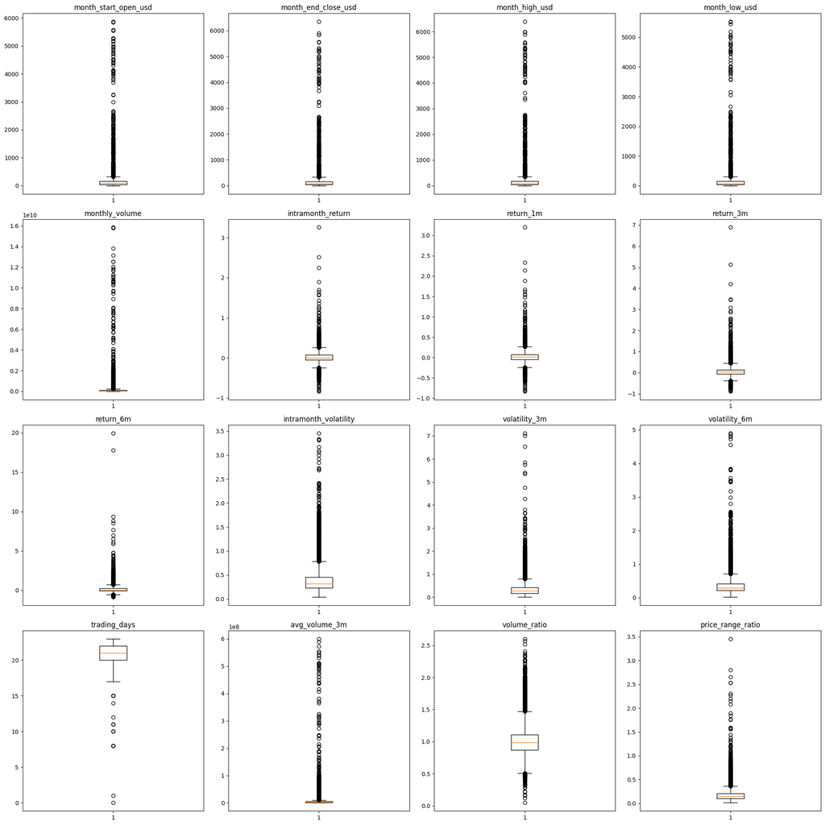

```python
# Select numeric columns
num_cols = stock_data.select_dtypes(include=['number']).columns

# Grid size (4x4)
n = len(num_cols)
rows, cols = 4, 4

fig, axes = plt.subplots(rows, cols, figsize=(20, 20))
axes = axes.flatten()

for i, col in enumerate(num_cols):
    axes[i].boxplot(stock_data[col].dropna())
    axes[i].set_title(col)

# Hide empty subplots if n < rows*cols
for j in range(i+1, rows*cols):
    fig.delaxes(axes[j])

plt.tight_layout()
plt.show()
```

**NOTE**: Dude why every data look like have outliers hahaha :(

Lance: I think the outliers are due to the volatility of the data. See the `stock_data.describe()`

###### Categorical Verification

[figure not shown]

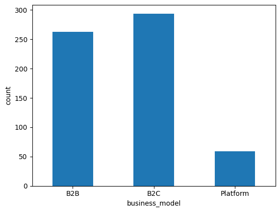

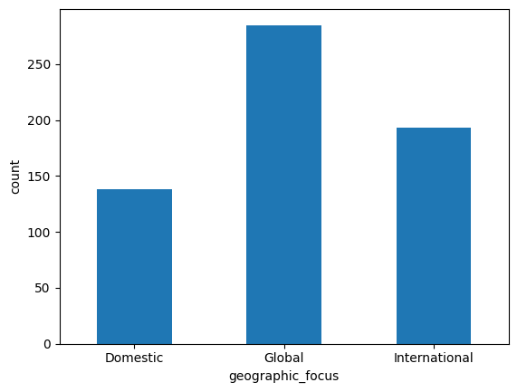

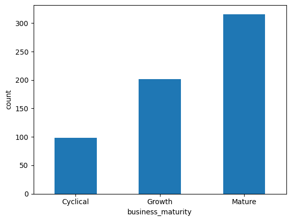

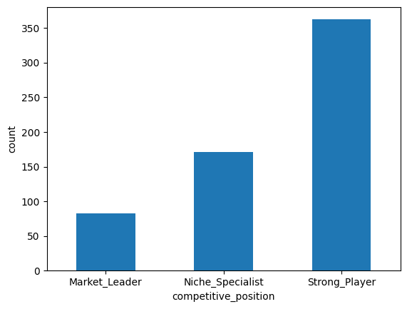

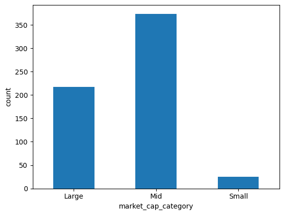

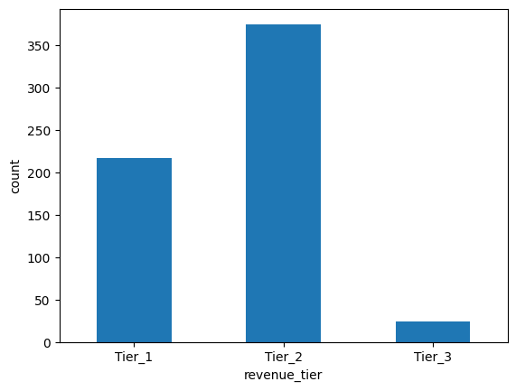

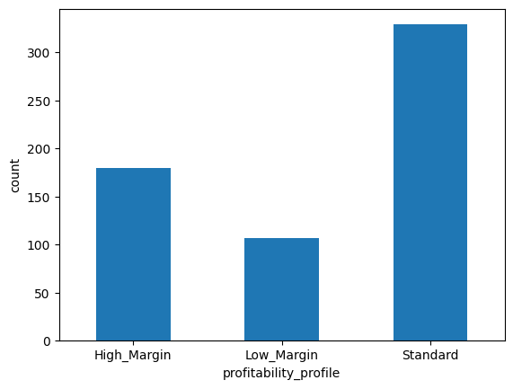

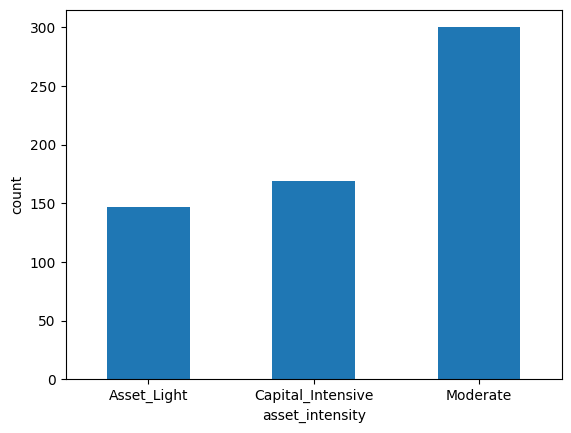

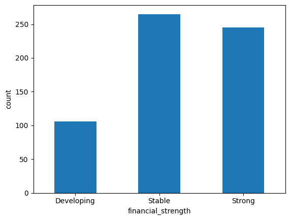

```python
# Plot counts of unique values of categorical variables
for col in company_info:
    if company_info[col].dtypes == 'object' and col != 'stock_id':
        company_info[col].value_counts().sort_index().plot(kind='bar', rot=0, ylabel='count', xlabel=col)
    plt.show()
```

Findings:

- `sector` supposed to be 11, but result in 12 sectors.
- Other object data are cross-checked with specfication document = valid

```python
company_info['sector'].value_counts()
```

| sector | count |
| --- | --- |
| Technology | 100 |
| Finance | 87 |
| Industrials | 86 |
| Healthcare | 83 |
| Consumer_Discretionary | 75 |
| Consumer_Staples | 40 |
| Utilities | 31 |
| Real_Estate | 31 |
| Energy | 29 |
| Communication | 28 |
| Materials | 25 |
| Other | 1 |

**dtype:** int64

'Other' sector with only 1 records is not matched with the list of sector provide in specification.

**NOTE**: See other context (data analysis or read document further) and confirm to lecturer team, does it need to be drop.

Other Sector refers to `stock_id = US610`. Do not drop

```python
company_info[company_info['sector'] == 'Other']
```

|  | stock_id | sector | business_model | geographic_focus | business_maturity | competitive_position | market_cap_category | revenue_tier | profitability_profile | asset_intensity | financial_strength |
| --- | --- | --- | --- | --- | --- | --- | --- | --- | --- | --- | --- |
| 586 | US610 | Other | B2B | Domestic | Growth | Niche_Specialist | Small | Tier_3 | High_Margin | Asset_Light | Stable |

```python
stock_data[stock_data['stock_id'] == 'US610'].head()
```

|  | stock_id | month_id | month_start_open_usd | month_end_close_usd | month_high_usd | month_low_usd | monthly_volume | intramonth_return | return_1m | return_3m | return_6m | intramonth_volatility | volatility_3m | volatility_6m | trading_days | avg_volume_3m | volume_ratio | price_range_ratio |
| --- | --- | --- | --- | --- | --- | --- | --- | --- | --- | --- | --- | --- | --- | --- | --- | --- | --- | --- |
| 24391 | US610 | 2020_01 | 11.187 | 8.785 | 11.236 | 8.717 | 315978273 | -0.214714 | -0.205083 | -0.209124 | -0.391742 | 0.371466 | 0.636766 | 0.539282 | 21 | 13469342.0 | 1.066 | 0.225108 |
| 24392 | US610 | 2020_02 | 8.814 | 7.776 | 9.570 | 7.185 | 272675193 | -0.117767 | -0.114829 | -0.388071 | -0.272114 | 0.489770 | 0.167174 | 0.446440 | 19 | 13501842.0 | 0.918 | 0.270565 |
| 24393 | US610 | 2020_03 | 7.902 | 6.118 | 8.319 | 4.402 | 470053969 | -0.225766 | -0.213217 | -0.446390 | -0.451112 | 1.219627 | 0.189168 | 0.472127 | 22 | 16041022.0 | 1.332 | 0.495706 |
| 24394 | US610 | 2020_04 | 5.924 | 7.447 | 7.941 | 5.672 | 321871637 | 0.257090 | 0.217116 | -0.152355 | -0.329617 | 0.566106 | 0.781093 | 0.639391 | 21 | 16130315.0 | 0.907 | 0.382979 |
| 24395 | US610 | 2020_05 | 7.185 | 7.805 | 8.533 | 6.679 | 252567627 | 0.086291 | 0.048174 | 0.003737 | -0.385784 | 0.788130 | 0.751069 | 0.581163 | 20 | 15825655.0 | 0.725 | 0.257957 |

# 2.3. Feature Engineering

```python
import random
SEED = 42
np.random.seed(SEED)
random.seed(SEED)
```

```python
# Import Library
from sklearn.preprocessing import StandardScaler, MinMaxScaler
```

```python
training_targets.head()
stock_data.sort_values(by='month_id', ascending=False).head()
```

|  | stock_id | month_id | month_start_open_usd | month_end_close_usd | month_high_usd | month_low_usd | monthly_volume | intramonth_return | return_1m | return_3m | return_6m | intramonth_volatility | volatility_3m | volatility_6m | trading_days | avg_volume_3m | volume_ratio | price_range_ratio |
| --- | --- | --- | --- | --- | --- | --- | --- | --- | --- | --- | --- | --- | --- | --- | --- | --- | --- | --- |
| 25617 | US650 | 2023_06 | 24.399 | 24.725 | 28.389 | 24.007 | 10748300 | 0.013361 | 0.019608 | -0.111321 | -0.196496 | 0.449686 | 0.172274 | 0.248056 | 21 | 631856 | 0.773 | 0.179595 |
| 11102 | US268 | 2023_06 | 58.662 | 59.127 | 60.004 | 56.302 | 65613378 | 0.007927 | 0.009435 | 0.015594 | -0.037006 | 0.189737 | 0.132787 | 0.113486 | 21 | 2390741 | 1.247 | 0.063108 |
| 16300 | US393 | 2023_06 | 52.626 | 53.144 | 54.981 | 51.998 | 105302700 | 0.009843 | 0.010183 | -0.04368 | -0.034097 | 0.133495 | 0.109272 | 0.160551 | 21 | 3760568 | 1.273 | 0.056677 |
| 14420 | US348 | 2023_06 | 5550.0 | 6350.62 | 6386.62 | 5520.48 | 507100 | 0.144256 | 0.143386 | 0.139699 | 0.376804 | 0.164989 | 0.333115 | 0.277773 | 21 | 23180 | 0.994 | 0.156061 |
| 5617 | US135 | 2023_06 | 62.369 | 63.09 | 66.467 | 60.818 | 192884000 | 0.01156 | 0.016169 | -0.062061 | -0.246919 | 0.35711 | 0.159289 | 0.157989 | 21 | 8256453 | 1.062 | 0.090577 |

```python
index.head()
```

|  | month_id | index_return | index_value |
| --- | --- | --- | --- |
| 0 | 2020_01 | -0.006452 | 99.354842 |
| 1 | 2020_02 | -0.053054 | 94.083684 |
| 2 | 2020_03 | -0.111379 | 83.604709 |
| 3 | 2020_04 | 0.141313 | 95.419099 |
| 4 | 2020_05 | 0.071232 | 102.215965 |

```python
company_info.head()
```

|  | stock_id | sector | business_model | geographic_focus | business_maturity | competitive_position | market_cap_category | revenue_tier | profitability_profile | asset_intensity | financial_strength |
| --- | --- | --- | --- | --- | --- | --- | --- | --- | --- | --- | --- |
| 0 | US001 | Industrials | B2B | Domestic | Mature | Market_Leader | Large | Tier_1 | Standard | Moderate | Stable |
| 1 | US002 | Industrials | B2B | Global | Growth | Strong_Player | Mid | Tier_2 | Standard | Capital_Intensive | Stable |
| 2 | US003 | Healthcare | B2C | Global | Mature | Market_Leader | Large | Tier_1 | High_Margin | Moderate | Stable |
| 3 | US004 | Healthcare | B2B | Global | Mature | Market_Leader | Large | Tier_1 | High_Margin | Asset_Light | Strong |
| 4 | US005 | Technology | B2B | Global | Mature | Market_Leader | Large | Tier_1 | High_Margin | Moderate | Strong |

## Categorical Processing

```python
from sklearn.preprocessing import OneHotEncoder
```

```python
import numpy as np
# Merge with company_info for more features
stock_company_data = stock_data.merge(company_info, on='stock_id', how='left')

# Get all categorical data (except for month_id)
categorical_features = [x for x in stock_company_data.columns if isinstance(stock_company_data[x].dtype, pd.StringDtype) and x != 'month_id']

# Get all numerical data
numerical_features = stock_company_data.select_dtypes(include=[np.number]).columns.tolist()
```

## Pipeline

Because several fields has really high range and high standard deviation which can be skew the result of analysis and model output. Standarization are needed.

```python
from sklearn.pipeline import make_pipeline, Pipeline
from sklearn.compose import ColumnTransformer
from sklearn.preprocessing import OneHotEncoder, StandardScaler, FunctionTransformer


# Features to standardize
cols_to_standardize = [
    "month_start_open_usd",
    "month_end_close_usd",
    "month_high_usd",
    "month_low_usd"
]

# Features to log transform
cols_to_log_transform = [
    'monthly_volume'
]

# Transformers
categorical_transformer = OneHotEncoder()
scaler = StandardScaler()
log_transformer = Pipeline([
    ('log', FunctionTransformer(lambda x: np.log1p(x))),
    ('scale', StandardScaler())
])

# Preprocess
preprocessor = ColumnTransformer(
    transformers = [
        ('ohe', categorical_transformer, categorical_features),
        ('std', scaler, cols_to_standardize),
        ('log', log_transformer, cols_to_log_transform)
    ]
)
```

```python
# Time-varying Columns
time_cols = [
    "month_start_open_usd",
    "month_end_close_usd",
    "month_high_usd",
    "month_low_usd",
    "monthly_volume",
    "intramonth_return",
    "return_1m", "return_3m", "return_6m",
    "intramonth_volatility", "volatility_3m", "volatility_6m",
    "trading_days",
    "avg_volume_3m", "volume_ratio", "price_range_ratio",
    "month_start_open_usd_std", "month_end_close_usd_std",
    "month_high_usd_std", "month_low_usd_std",
    "monthly_volume_log_std", "monthly_volume_minmax",
    "monthly_volume_log_minmax"
]

# We can use function later to compute time_cols based on = x for x in stock_data not in ['stock_id', 'month_id']
```

```python
import numpy as np
import pandas as pd
from sklearn.pipeline import Pipeline
from sklearn.compose import ColumnTransformer
from sklearn.preprocessing import StandardScaler, MinMaxScaler, FunctionTransformer

# --- columns you defined ---
cols_to_standardize = [
    "month_start_open_usd",
    "month_end_close_usd",
    "month_high_usd",
    "month_low_usd",
]
cols_to_log_std = ["monthly_volume"]
cols_to_minmax = ["monthly_volume"]
cols_to_log_minmax = ["monthly_volume"]

# --- preprocessors ---
std_block = Pipeline([
    ("scaler", StandardScaler())
])

log_std_block = Pipeline([
    ("log1p", FunctionTransformer(np.log1p, feature_names_out="one-to-one", validate=False)),
    ("scaler", StandardScaler())
])

minmax_block = Pipeline([
    ("scaler", MinMaxScaler())
])

log_minmax_block = Pipeline([
    ("log1p", FunctionTransformer(np.log1p, feature_names_out="one-to-one", validate=False)),
    ("scaler", MinMaxScaler())
])

# ColumnTransformer handles all four transformations
preprocessor = ColumnTransformer(
    transformers=[
        ("std", std_block, cols_to_standardize),
        ("log_std", log_std_block, cols_to_log_std),
        ("minmax", minmax_block, cols_to_minmax),
        ("log_minmax", log_minmax_block, cols_to_log_minmax),
    ],
    remainder="passthrough",
    verbose_feature_names_out=True
)

# Return DataFrame instead of numpy array (scikit-learn >= 1.2)
preprocessor.set_output(transform="pandas")

# Wrap inside pipeline
pipe = Pipeline([
    ("features", preprocessor)
])

# --- fit & transform ---
X_out = pipe.fit_transform(stock_data)

# (Optional) rename engineered features to your suffix style
def rename_engineered_columns(df: pd.DataFrame) -> pd.DataFrame:
    rename_map = {}
    for c in df.columns:
        if c.startswith("std_"):
            base = c.split("_", 1)[1]
            rename_map[c] = f"{base}_std"
        elif c.startswith("log_std_"):
            base = c.split("_", 1)[1]
            rename_map[c] = f"{base}_log_std"
        elif c.startswith("minmax_"):
            base = c.split("_", 1)[1]
            rename_map[c] = f"{base}_minmax"
        elif c.startswith("log_minmax_"):
            base = c.split("_", 1)[1]
            rename_map[c] = f"{base}_log_minmax"
    return df.rename(columns=rename_map)

stock_data_engineered = rename_engineered_columns(X_out)

# Inspect result
stock_data_engineered.info()
```

```
<class 'pandas.core.frame.DataFrame'>
RangeIndex: 25618 entries, 0 to 25617
Data columns (total 20 columns):
 #   Column                             Non-Null Count  Dtype
---  ------                             --------------  -----
 0   _month_start_open_usd_std          25618 non-null  float64
 1   _month_end_close_usd_std           25618 non-null  float64
 2   _month_high_usd_std                25618 non-null  float64
 3   _month_low_usd_std                 25618 non-null  float64
 4   std__monthly_volume_log_std        25618 non-null  float64
 5   _monthly_volume_minmax             25618 non-null  float64
 6   minmax__monthly_volume_log_minmax  25618 non-null  float64
 7   remainder__stock_id                25618 non-null  string
 8   remainder__month_id                25618 non-null  string
 9   remainder__intramonth_return       25618 non-null  Float64
 10  remainder__return_1m               25597 non-null  Float64
 11  remainder__return_3m               25555 non-null  Float64
 12  remainder__return_6m               25483 non-null  Float64
 13  remainder__intramonth_volatility   25616 non-null  Float64
 14  remainder__volatility_3m           25555 non-null  Float64
 15  remainder__volatility_6m           25483 non-null  Float64
 16  remainder__trading_days            25618 non-null  Int64
 17  remainder__avg_volume_3m           25576 non-null  Int64
 18  remainder__volume_ratio            25576 non-null  Float64
 19  remainder__price_range_ratio       25618 non-null  Float64
dtypes: Float64(9), Int64(2), float64(7), string(2)
memory usage: 4.2 MB
```

## Normalization

**NOTE**: Suitable for Regression, PCA, tree-based, linear model

Log Transform Normalization + Standardization

```python
# Import Library
import numpy as np
```

```python
# Features to standardize
cols_to_standardize = [
    "month_start_open_usd",
    "month_end_close_usd",
    "month_high_usd",
    "month_low_usd"
]

scaler = StandardScaler()

# Fit and transform selected columns
stock_data_std = scaler.fit_transform(stock_data[cols_to_standardize])

# Add standardized features to the new DataFrame
stock_data_1 = stock_data.copy(deep=True)

for i, col in enumerate(cols_to_standardize):
    stock_data_1[f"{col}_std"] = stock_data_std[:, i]

# Check result
stock_data_1.info()
```

```
<class 'pandas.core.frame.DataFrame'>
RangeIndex: 25618 entries, 0 to 25617
Data columns (total 22 columns):
 #   Column                    Non-Null Count  Dtype
---  ------                    --------------  -----
 0   stock_id                  25618 non-null  string
 1   month_id                  25618 non-null  string
 2   month_start_open_usd      25618 non-null  Float64
 3   month_end_close_usd       25618 non-null  Float64
 4   month_high_usd            25618 non-null  Float64
 5   month_low_usd             25618 non-null  Float64
 6   monthly_volume            25618 non-null  Int64
 7   intramonth_return         25618 non-null  Float64
 8   return_1m                 25597 non-null  Float64
 9   return_3m                 25555 non-null  Float64
 10  return_6m                 25483 non-null  Float64
 11  intramonth_volatility     25616 non-null  Float64
 12  volatility_3m             25555 non-null  Float64
 13  volatility_6m             25483 non-null  Float64
 14  trading_days              25618 non-null  Int64
 15  avg_volume_3m             25576 non-null  Int64
 16  volume_ratio              25576 non-null  Float64
 17  price_range_ratio         25618 non-null  Float64
 18  month_start_open_usd_std  25618 non-null  float64
 19  month_end_close_usd_std   25618 non-null  float64
 20  month_high_usd_std        25618 non-null  float64
 21  month_low_usd_std         25618 non-null  float64
dtypes: Float64(13), Int64(3), float64(4), string(2)
memory usage: 4.7 MB
```

```python
stock_data_2 = stock_data_1.copy()

# Features to log-transform + standardize
cols_to_log_std = ["monthly_volume"]

scaler = StandardScaler()

for col in cols_to_log_std:
    # Step 1: log transform (log1p to handle 0 safely)
    log_values = np.log1p(stock_data[col])

    # Step 2: standardize
    standardized = scaler.fit_transform(log_values.values.reshape(-1, 1))

    # Step 3: add to new DataFrame
    stock_data_2[f"{col}_log_std"] = standardized

# ✅ Check result
stock_data_2.info()
```

```
<class 'pandas.core.frame.DataFrame'>
RangeIndex: 25618 entries, 0 to 25617
Data columns (total 23 columns):
 #   Column                    Non-Null Count  Dtype
---  ------                    --------------  -----
 0   stock_id                  25618 non-null  string
 1   month_id                  25618 non-null  string
 2   month_start_open_usd      25618 non-null  Float64
 3   month_end_close_usd       25618 non-null  Float64
 4   month_high_usd            25618 non-null  Float64
 5   month_low_usd             25618 non-null  Float64
 6   monthly_volume            25618 non-null  Int64
 7   intramonth_return         25618 non-null  Float64
 8   return_1m                 25597 non-null  Float64
 9   return_3m                 25555 non-null  Float64
 10  return_6m                 25483 non-null  Float64
 11  intramonth_volatility     25616 non-null  Float64
 12  volatility_3m             25555 non-null  Float64
 13  volatility_6m             25483 non-null  Float64
 14  trading_days              25618 non-null  Int64
 15  avg_volume_3m             25576 non-null  Int64
 16  volume_ratio              25576 non-null  Float64
 17  price_range_ratio         25618 non-null  Float64
 18  month_start_open_usd_std  25618 non-null  float64
 19  month_end_close_usd_std   25618 non-null  float64
 20  month_high_usd_std        25618 non-null  float64
 21  month_low_usd_std         25618 non-null  float64
 22  monthly_volume_log_std    25618 non-null  float64
dtypes: Float64(13), Int64(3), float64(5), string(2)
memory usage: 4.9 MB
```

**NOTE**: suitable for KNN, SVM, Neural Nets

## Min-Max Scaler

```python
stock_data_3 = stock_data_1.copy()

# Features to min-max scale
cols_to_minmax = ["monthly_volume"]

scaler = MinMaxScaler()

# Fit & transform selected columns
scaled = scaler.fit_transform(stock_data[cols_to_minmax])

# Add scaled features back to DataFrame
for i, col in enumerate(cols_to_minmax):
    stock_data_3[f"{col}_minmax"] = scaled[:, i]

# Check result
stock_data_3.info()
```

```
<class 'pandas.core.frame.DataFrame'>
RangeIndex: 25618 entries, 0 to 25617
Data columns (total 23 columns):
 #   Column                    Non-Null Count  Dtype
---  ------                    --------------  -----
 0   stock_id                  25618 non-null  string
 1   month_id                  25618 non-null  string
 2   month_start_open_usd      25618 non-null  Float64
 3   month_end_close_usd       25618 non-null  Float64
 4   month_high_usd            25618 non-null  Float64
 5   month_low_usd             25618 non-null  Float64
 6   monthly_volume            25618 non-null  Int64
 7   intramonth_return         25618 non-null  Float64
 8   return_1m                 25597 non-null  Float64
 9   return_3m                 25555 non-null  Float64
 10  return_6m                 25483 non-null  Float64
 11  intramonth_volatility     25616 non-null  Float64
 12  volatility_3m             25555 non-null  Float64
 13  volatility_6m             25483 non-null  Float64
 14  trading_days              25618 non-null  Int64
 15  avg_volume_3m             25576 non-null  Int64
 16  volume_ratio              25576 non-null  Float64
 17  price_range_ratio         25618 non-null  Float64
 18  month_start_open_usd_std  25618 non-null  float64
 19  month_end_close_usd_std   25618 non-null  float64
 20  month_high_usd_std        25618 non-null  float64
 21  month_low_usd_std         25618 non-null  float64
 22  monthly_volume_minmax     25618 non-null  float64
dtypes: Float64(13), Int64(3), float64(5), string(2)
memory usage: 4.9 MB
```

Log-Transform + Min-Max Scaler

```python
stock_data_4 = stock_data_1.copy()

# Features to log-transform + min-max scale
cols_to_log_minmax = ["monthly_volume"]

scaler = MinMaxScaler()

for col in cols_to_log_minmax:
    # Step 1: log transform (handle 0 safely)
    log_values = np.log1p(stock_data[col])

    # Step 2: Min-Max scale to [0,1]
    scaled = scaler.fit_transform(log_values.values.reshape(-1, 1))

    # Step 3: add new feature
    stock_data_4[f"{col}_log_minmax"] = scaled

# Check result
stock_data_4.info()
```

```
<class 'pandas.core.frame.DataFrame'>
RangeIndex: 25618 entries, 0 to 25617
Data columns (total 23 columns):
 #   Column                     Non-Null Count  Dtype
---  ------                     --------------  -----
 0   stock_id                   25618 non-null  string
 1   month_id                   25618 non-null  string
 2   month_start_open_usd       25618 non-null  Float64
 3   month_end_close_usd        25618 non-null  Float64
 4   month_high_usd             25618 non-null  Float64
 5   month_low_usd              25618 non-null  Float64
 6   monthly_volume             25618 non-null  Int64
 7   intramonth_return          25618 non-null  Float64
 8   return_1m                  25597 non-null  Float64
 9   return_3m                  25555 non-null  Float64
 10  return_6m                  25483 non-null  Float64
 11  intramonth_volatility      25616 non-null  Float64
 12  volatility_3m              25555 non-null  Float64
 13  volatility_6m              25483 non-null  Float64
 14  trading_days               25618 non-null  Int64
 15  avg_volume_3m              25576 non-null  Int64
 16  volume_ratio               25576 non-null  Float64
 17  price_range_ratio          25618 non-null  Float64
 18  month_start_open_usd_std   25618 non-null  float64
 19  month_end_close_usd_std    25618 non-null  float64
 20  month_high_usd_std         25618 non-null  float64
 21  month_low_usd_std          25618 non-null  float64
 22  monthly_volume_log_minmax  25618 non-null  float64
dtypes: Float64(13), Int64(3), float64(5), string(2)
memory usage: 4.9 MB
```

```python
# Lag Features
stock_lag = stock_data_4.sort_values(["stock_id", "month_id"])

for c in time_cols:
    stock_lag[f"{c}_lag1"] = stock_lag.groupby("stock_id")[c].shift(1)
```

[output not shown]

```python
# Drop unlagged columns
lag_cols = [f"{c}_lag1" for c in time_cols]
stock_lag = stock_lag[["stock_id", "month_id"] + lag_cols]
```

[output not shown]

#### 3. Data Preparation

**Monthly Excess Return**

##### 3.1. Classification Model - Data Preparation

### Defining Target Variable

```python
index.tail()
#index[index['month_id'] == '2023_06']
```

|  | month_id | index_return | index_value |
| --- | --- | --- | --- |
| 37 | 2023_02 | -0.014666 | 129.221187 |
| 38 | 2023_03 | 0.004782 | 129.83917 |
| 39 | 2023_04 | -0.001434 | 129.652939 |
| 40 | 2023_05 | -0.005923 | 128.885022 |
| 41 | 2023_06 | 0.053319 | 135.757066 |

```python
training_targets.info()
testing_targets.info()
```

```
<class 'pandas.core.frame.DataFrame'>
RangeIndex: 25618 entries, 0 to 25617
Data columns (total 4 columns):
 #   Column             Non-Null Count  Dtype
---  ------             --------------  -----
 0   month_id           25618 non-null  string
 1   stock_id           25618 non-null  string
 2   outperform_binary  25618 non-null  Int64
 3   excess_return      25618 non-null  Float64
dtypes: Float64(1), Int64(1), string(2)
memory usage: 850.7 KB
<class 'pandas.core.frame.DataFrame'>
RangeIndex: 616 entries, 0 to 615
Data columns (total 4 columns):
 #   Column             Non-Null Count  Dtype
---  ------             --------------  -----
 0   month_id           616 non-null    string
 1   stock_id           616 non-null    string
 2   outperform_binary  0 non-null      Int64
 3   excess_return      0 non-null      Int64
dtypes: Int64(2), string(2)
memory usage: 20.6 KB
```

##### 3.2. Regression Model - Data Preparation

# 4. Classification Task

```python
target_column = 'outperform_binary'
stock_company_data.info()
training_targets.info()
```

```
<class 'pandas.core.frame.DataFrame'>
RangeIndex: 25618 entries, 0 to 25617
Data columns (total 28 columns):
 #   Column                 Non-Null Count  Dtype
---  ------                 --------------  -----
 0   stock_id               25618 non-null  string
 1   month_id               25618 non-null  string
 2   month_start_open_usd   25618 non-null  Float64
 3   month_end_close_usd    25618 non-null  Float64
 4   month_high_usd         25618 non-null  Float64
 5   month_low_usd          25618 non-null  Float64
 6   monthly_volume         25618 non-null  Int64
 7   intramonth_return      25618 non-null  Float64
 8   return_1m              25597 non-null  Float64
 9   return_3m              25555 non-null  Float64
 10  return_6m              25483 non-null  Float64
 11  intramonth_volatility  25616 non-null  Float64
 12  volatility_3m          25555 non-null  Float64
 13  volatility_6m          25483 non-null  Float64
 14  trading_days           25618 non-null  Int64
 15  avg_volume_3m          25576 non-null  Int64
 16  volume_ratio           25576 non-null  Float64
 17  price_range_ratio      25618 non-null  Float64
 18  sector                 25618 non-null  string
 19  business_model         25618 non-null  string
 20  geographic_focus       25618 non-null  string
 21  business_maturity      25618 non-null  string
 22  competitive_position   25618 non-null  string
 23  market_cap_category    25618 non-null  string
 24  revenue_tier           25618 non-null  string
 25  profitability_profile  25618 non-null  string
 26  asset_intensity        25618 non-null  string
 27  financial_strength     25618 non-null  string
dtypes: Float64(13), Int64(3), string(12)
memory usage: 5.9 MB
<class 'pandas.core.frame.DataFrame'>
RangeIndex: 25618 entries, 0 to 25617
Data columns (total 4 columns):
 #   Column             Non-Null Count  Dtype
---  ------             --------------  -----
 0   month_id           25618 non-null  string
 1   stock_id           25618 non-null  string
 2   outperform_binary  25618 non-null  Int64
 3   excess_return      25618 non-null  Float64
dtypes: Float64(1), Int64(1), string(2)
memory usage: 850.7 KB
```

```python
from sklearn.metrics import f1_score, classification_report
from sklearn.model_selection import train_test_split

def evaluate_pipeline(pipe, X, target_column, test_size=0.2, random_state=42, average="binary"):
    """
    Fit a pipeline, evaluate with F1 score on a holdout set, and print results.

    Parameters
    ----------
    pipe : sklearn Pipeline
        A pipeline with preprocessing + model.
    X : pd.DataFrame
        Features (before preprocessing).
    y : pd.Series
        Target labels.
    test_size : float
        Proportion for test split.
    random_state : int
        Seed for reproducibility.
    average : str
        'binary' for binary classification, or 'macro'/'micro'/'weighted' for multi-class.

    Returns
    -------
    f1 : float
        F1 score on the test set.
    report : str
        Text classification report.
    """
   # --- Step 1: Merge target ---
    merged = pd.merge(X, training_targets, on=["stock_id", "month_id"], how="inner")

    # --- Step 2: Drop rows with NA in features ---
    merged = merged.dropna()

    # --- Step 3: Prepare features and target ---
    y = merged[target_column]
    drop_cols = ['month_id', 'outperform_binary', 'excess_return']
    X = merged.drop(columns=drop_cols, errors='ignore')

    # --- Step 4: Train-test split ---
    X_train, X_test, y_train, y_test = train_test_split(X, y, test_size=0.2, random_state=42)

    # Fit pipeline
    pipe.fit(X_train, y_train)

    # Predict
    y_pred = pipe.predict(X_test)

    # Compute F1
    f1 = f1_score(y_test, y_pred, average=average)

    print(f"📊 {pipe.named_steps['model'].__class__.__name__} → F1 Score = {f1:.4f}")
    print(classification_report(y_test, y_pred))

    return f1
```

```python
from sklearn.linear_model import LogisticRegression
# LogisticRegression
pipeLR = Pipeline(steps=[
    ('preprocess', preprocessor),
    ('model', LogisticRegression(max_iter=500))
])

LR_f1 = evaluate_pipeline(pipeLR, stock_company_data, target_column, average="binary")

print(f'Logistic Regression Full Model (no month) (500 iterations):{LR_f1}')
```

```
📊 LogisticRegression → F1 Score = 0.8097
              precision    recall  f1-score   support

         0.0       0.81      0.84      0.83      2615
         1.0       0.82      0.80      0.81      2482

    accuracy                           0.82      5097
   macro avg       0.82      0.82      0.82      5097
weighted avg       0.82      0.82      0.82      5097

Logistic Regression Full Model (no month) (500 iterations):0.8096701495595164
```

```python
from sklearn.linear_model import LogisticRegression
from sklearn.ensemble import RandomForestClassifier
from sklearn.svm import SVC
from sklearn.neighbors import KNeighborsClassifier
from sklearn.naive_bayes import GaussianNB

from sklearn.model_selection import train_test_split
from sklearn.metrics import f1_score

# Function to evaluate classification models
def evaluate_classification_models(feature_data, dataset_name=""):
    # --- Step 1: Merge target ---
    merged = pd.merge(feature_data, train_targets, on=["stock_id", "month_id"], how="inner")

    # --- Step 2: Drop rows with NA in features ---
    merged = merged.dropna()

    # --- Step 3: Prepare features and target ---
    y = merged[target_column]
    drop_cols = ['stock_id', 'month_id', 'outperform_binary', 'excess_return']
    X = merged.drop(columns=drop_cols, errors='ignore')

    # --- Step 4: Train-test split ---
    X_train, X_test, y_train, y_test = train_test_split(X, y, test_size=0.2, random_state=42)

    # --- Step 5: Define models ---
    models = {
        "Logistic Regression": LogisticRegression(max_iter=500),
        "Random Forest": RandomForestClassifier(n_estimators=100),
        "SVM (RBF Kernel)": SVC(kernel='rbf'),
        "K-Nearest Neighbors": KNeighborsClassifier(n_neighbors=5),
        "Naive Bayes": GaussianNB()
    }

    print(f"\n📊 Classification Results for: {dataset_name}")

    # Use Pipelines

    for name, model in models.items():
        model.fit(X_train, y_train)
        y_pred = model.predict(X_test)
        f1 = f1_score(y_test, y_pred)
        print(f"{name:<25} → F1 Score = {f1:.4f}")
```

```python
# --- Evaluate both datasets ---
evaluate_classification_models(stock_data_3, "Min-Max Scaled")
evaluate_classification_models(stock_data_4, "Log + Min-Max Scaled")
```

```
📊 Classification Results for: Min-Max Scaled
Logistic Regression       → F1 Score = 0.6550
Random Forest             → F1 Score = 0.8930
SVM (RBF Kernel)          → F1 Score = 0.0087
K-Nearest Neighbors       → F1 Score = 0.4905
Naive Bayes               → F1 Score = 0.0508

📊 Classification Results for: Log + Min-Max Scaled
Logistic Regression       → F1 Score = 0.6550
Random Forest             → F1 Score = 0.8982
SVM (RBF Kernel)          → F1 Score = 0.0087
K-Nearest Neighbors       → F1 Score = 0.4905
Naive Bayes               → F1 Score = 0.0508
```

The results of initial models (including all the features):

- There are not much significant differences of normalization steps of 1 and 2.
- On both dataset, Random Forest show the most promising performance one.

As this is initial model with using all the features, the possibility of overfitting due to curse of dimensionality is high. Model selection algorithm such as: Best Model Selection, Forward or Backward Stepwise are required.

Also other relationships analysis such as correlation features to target and other mandatory analyses listed in the specification document are need to be explored.

Also need to confirm with test data in submission of kaggle (59% of test data) to check generalization capability of our model.

Model Tuning:

- Random Forest (F1 ≈ 0.89) -> Potentially our best model
- Logistic Regression (F1 ≈ 0.655) -> Good Baseline -> Best Features Selection
- K-Nearest Neighbors (F1 ≈ 0.49) -> tune n_neighbors
- Support Vector Machine (F1 ≈ 0.0087) -> Poor scaling for SVM, incorrect kernel (try linear), tune C, gamma, epsilon
- Naive Bayes (F1 ≈ 0.05) -> Assumes feature independence and Gaussian distributions -> Standarization or Skip ?

##### 4.1. Model Selection

###### 4.1.1. Logistic Regression

Forward Stepwise Feature Selection

Backward Stepwise Feature Selection

###### 4.1.2. Random Forest

Forward Stepwise

Backward Stepwise

###### 4.1.3. Support Vector Machine (SVM)

Forward Stepwise

Backward Stepwise

###### 4.1.4. K-Nearest Neighbors (KNN)

Forward Stepwise

Backward Stepwise

###### 4.1.5. Naive Bayes

Forward Stepwise

Backward Stepwise

##### 4.2. Evaluation

# 5. Regression Task

```python
SEED = 42
```

```python
testing_targets.head()
```

|  | month_id | stock_id | outperform_binary | excess_return |
| --- | --- | --- | --- | --- |
| 0 | 2023_07 | US001 | <NA> | <NA> |
| 1 | 2023_07 | US002 | <NA> | <NA> |
| 2 | 2023_07 | US003 | <NA> | <NA> |
| 3 | 2023_07 | US004 | <NA> | <NA> |
| 4 | 2023_07 | US005 | <NA> | <NA> |

```python
# Import libraries
import numpy as np
import math
from sklearn.model_selection import TimeSeriesSplit, GridSearchCV, cross_val_score
from sklearn.preprocessing import StandardScaler, OneHotEncoder, RobustScaler, FunctionTransformer
from sklearn.compose import ColumnTransformer
from sklearn.pipeline import Pipeline
from sklearn.linear_model import Ridge, Lasso, LinearRegression, LassoCV
from sklearn.metrics import mean_squared_error
from sklearn.svm import SVR
```

## Simple Model

### Datasets

```python
# Merging Datasets
stock_company_data = stock_data.merge(company_info, on=['stock_id'], how='left')

stock_company_data = stock_company_data.sort_values(['stock_id', 'month_id'])
```

```python
stock_company_data.dtypes
```

```
stock_id                 string[python]
month_id                 string[python]
month_start_open_usd            Float64
month_end_close_usd             Float64
month_high_usd                  Float64
month_low_usd                   Float64
monthly_volume                    Int64
intramonth_return               Float64
return_1m                       Float64
return_3m                       Float64
return_6m                       Float64
intramonth_volatility           Float64
volatility_3m                   Float64
volatility_6m                   Float64
trading_days                      Int64
avg_volume_3m                     Int64
volume_ratio                    Float64
price_range_ratio               Float64
sector                   string[python]
business_model           string[python]
geographic_focus         string[python]
business_maturity        string[python]
competitive_position     string[python]
market_cap_category      string[python]
revenue_tier             string[python]
profitability_profile    string[python]
asset_intensity          string[python]
financial_strength       string[python]
dtype: object
```

### Feature Engineering

Creating Lag Features

```python
stock_company_data.head()
```

|  | stock_id | month_id | month_start_open_usd | month_end_close_usd | month_high_usd | month_low_usd | monthly_volume | intramonth_return | return_1m | return_3m | return_6m | intramonth_volatility | volatility_3m | volatility_6m | trading_days | avg_volume_3m | volume_ratio | price_range_ratio | sector | business_model | geographic_focus | business_maturity | competitive_position | market_cap_category | revenue_tier | profitability_profile | asset_intensity | financial_strength |
| --- | --- | --- | --- | --- | --- | --- | --- | --- | --- | --- | --- | --- | --- | --- | --- | --- | --- | --- | --- | --- | --- | --- | --- | --- | --- | --- | --- | --- |
| 0 | US001 | 2020_01 | 120.192 | 107.326 | 123.486 | 107.035 | 84539259 | -0.107045 | -0.100669 | -0.030041 | -0.075676 | 0.253304 | 0.278396 | 0.201608 | 21 | 3182487 | 1.207 | 0.136875 | Industrials | B2B | Domestic | Mature | Market_Leader | Large | Tier_1 | Standard | Moderate | Stable |
| 1 | US001 | 2020_02 | 108.252 | 101.868 | 111.641 | 99.636 | 91313882 | -0.058974 | -0.050854 | -0.112968 | -0.060752 | 0.259208 | 0.245523 | 0.192782 | 19 | 3686371 | 1.126 | 0.110905 | Industrials | B2B | Domestic | Mature | Market_Leader | Large | Tier_1 | Standard | Moderate | Stable |
| 2 | US001 | 2020_03 | 103.301 | 93.178 | 105.622 | 77.841 | 177930833 | -0.097995 | -0.085299 | -0.219214 | -0.154874 | 0.892709 | 0.088364 | 0.213051 | 22 | 5360363 | 1.509 | 0.268931 | Industrials | B2B | Domestic | Mature | Market_Leader | Large | Tier_1 | Standard | Moderate | Stable |
| 3 | US001 | 2020_04 | 90.1 | 103.697 | 111.314 | 89.424 | 98448862 | 0.15091 | 0.112885 | -0.03381 | -0.062835 | 0.408352 | 0.366808 | 0.291241 | 21 | 5571115 | 0.803 | 0.242954 | Industrials | B2B | Domestic | Mature | Market_Leader | Large | Tier_1 | Standard | Moderate | Stable |
| 4 | US001 | 2020_05 | 101.909 | 107.841 | 110.206 | 89.499 | 103380207 | 0.058209 | 0.039966 | 0.058641 | -0.060951 | 0.419368 | 0.347233 | 0.29204 | 20 | 5753938 | 0.817 | 0.203186 | Industrials | B2B | Domestic | Mature | Market_Leader | Large | Tier_1 | Standard | Moderate | Stable |

```python
# Get all categorical data (except for month_id)
categorical_features = [x for x in stock_company_data.columns if isinstance(stock_company_data[x].dtype, pd.StringDtype) and x not in ['month_id', 'stock_id']]

# Get all numerical data
numerical_features = stock_company_data.select_dtypes(include=[np.number]).columns.tolist()
```

```python
stock_lag = stock_company_data.sort_values(["stock_id", "month_id"])

# Build up to 12 months of lag
for c in numerical_features:
    for L in range(1,13):
        stock_lag[f'{c}_lag{L}'] = stock_lag.groupby('stock_id')[c].shift(L)
```

```python
training_targets.head()
```

|  | month_id | stock_id | outperform_binary | excess_return |
| --- | --- | --- | --- | --- |
| 0 | 2020_01 | US001 | 0 | -0.100593 |
| 1 | 2020_02 | US001 | 0 | -0.00592 |
| 2 | 2020_03 | US001 | 1 | 0.013384 |
| 3 | 2020_04 | US001 | 1 | 0.009597 |
| 4 | 2020_05 | US001 | 0 | -0.013023 |

```python
# Building Training Table
categorical_features = [x for x in stock_lag.columns if isinstance(stock_lag[x].dtype, pd.StringDtype) and x not in ['month_id', 'stock_id']]
numerical_features = stock_lag.select_dtypes(include=[np.number]).columns.tolist()

train = stock_lag.merge(training_targets, on=['month_id', 'stock_id'], how='inner')

train.dropna(inplace=True)
train = train.sort_values(by=['month_id', 'stock_id']).reset_index(drop=True)

feature_cols = categorical_features + numerical_features
X = train[feature_cols].copy()
y = train['excess_return'].copy()
```

Strategy

- Return / Volatility lags -> using RobustScaler() which makes it less sensitive to spikes
- Volume-related lags -> applying `log1p` with `StandardScaler()`
- Categorical Data -> `OneHotEncoder()`

```python
return_volatility_features = [c for c in X.columns if 'return' in c or 'volatility' in c]
volume_features = [c for c in X.columns if 'volume' in c]
```

```python
remaining_numerical = [c for c in numerical_features if c not in volume_features + return_volatility_features]
```

```python
# Preprocessor
pre = ColumnTransformer(
    transformers=[
        ('returns_volatilty', RobustScaler(), return_volatility_features),
        ('volumes', Pipeline([
            ('log', FunctionTransformer(np.log1p, validate=False)),
            ('scaler', StandardScaler())
        ]), volume_features),
        ('num', StandardScaler(), remaining_numerical),
        ('ohe', OneHotEncoder(), categorical_features)
    ])

# Models
models = {
        'ridge': (Ridge(random_state=SEED),
              {'model__alpha': [0.001, 0.01, 0.1, 1.0, 10.0, 100.0]}),
    'lasso': (Lasso(random_state=SEED, max_iter=100000),
              {'model__alpha': [0.001, 0.01, 0.1, 1.0, 10.0, 100.0]})

}
```

```python
# Time series cvb
tscv = TimeSeriesSplit(n_splits=5)
```

```python
for name, (model, param_grid) in models.items():
    pipe = Pipeline(steps=[("pre", pre),
                           ("model", model)])

    grid = GridSearchCV(
        estimator=pipe,
        param_grid=param_grid,
        cv=tscv,
        scoring="neg_root_mean_squared_error",
        n_jobs=-1
    )
    grid.fit(X, y)

    print(f"\nModel: {name}")
    print("Best Params:", grid.best_params_)
    print("Best CV RMSE:", -grid.best_score_)
```

```
Model: ridge
Best Params: {'model__alpha': 100.0}
Best CV RMSE: 0.04025882183999969

Model: lasso
Best Params: {'model__alpha': 0.01}
Best CV RMSE: 0.031714640617244924
```

Use the Best Model: Best CV RMSE is Lasso when alpha = 0.01

moderate alpha, some coefficients shrink, reduces variance helps prevent overfitting

Data might be overfitting as the RMSE is too low.

## Using Optional Data

- fed_funds
- fed_inflation
- fed_unemployment
- us_10year
- us_5year
- vix_index

```python
full_dataset = stock_company_data.merge(fed_funds, on=['month_id'], how='left')
full_dataset = full_dataset.merge(fed_inflation, on=['month_id'], how='left')
full_dataset = full_dataset.merge(fed_unemployment, on=['month_id'], how='left')
full_dataset = full_dataset.merge(us_10year, on=['month_id'], how='left')
full_dataset = full_dataset.merge(us_5year, on=['month_id'], how='left')
full_dataset = full_dataset.merge(vix_index, on=['month_id'], how='left')
```

```python
# Time-varying Columns
time_cols = [
    "month_start_open_usd",
    "month_end_close_usd",
    "month_high_usd",
    "month_low_usd",
    "monthly_volume",
    "intramonth_return",
    "return_1m", "return_3m", "return_6m",
    "intramonth_volatility", "volatility_3m", "volatility_6m",
    "trading_days"
]

# Get all categorical data (except for month_id and stock_id)
categorical_features = [x for x in full_dataset.columns if isinstance(full_dataset[x].dtype, pd.StringDtype) and x not in ['month_id', 'stock_id']]

# Get all numerical data
numerical_features = full_dataset.select_dtypes(include=[np.number]).columns.tolist()
```

```python
full_dataset = full_dataset.sort_values(["stock_id", "month_id"])

# Build up to 12 months of lag
for c in time_cols:
    for L in range(1,13):
        full_dataset[f'{c}_lag{L}'] = full_dataset.groupby('stock_id')[c].shift(L)
```

```python
# Building Training Table
categorical_features = [x for x in full_dataset.columns if isinstance(full_dataset[x].dtype, pd.StringDtype) and x not in ['month_id', 'stock_id']]
numerical_features = full_dataset.select_dtypes(include=[np.number]).columns.tolist()

train = full_dataset.merge(training_targets, on=['month_id', 'stock_id'], how='inner')

train['month_id'] = pd.to_datetime(train['month_id'], format='%Y_%m')

# Drop stock_id (or only use to group when creating lags)
X = train.drop(columns=["stock_id","month_id"])

# Add cyclical encoding for month
train["month_num"] = train["month_id"].astype(str).str[-2:].astype(int)
train["month_sin"] = np.sin(2*np.pi*train["month_num"]/12)
train["month_cos"] = np.cos(2*np.pi*train["month_num"]/12)


train.dropna(inplace=True)
train = train.sort_values(by=['month_id', 'stock_id']).reset_index(drop=True)

categorical_features.append('month_num')
numerical_features.extend(['month_sin', 'month_cos'])

feature_cols = categorical_features + numerical_features
X = train[feature_cols].copy()
y = train['excess_return'].copy()
```

```
Top correlations with excess_return:
excess_return                  1.000000
intramonth_return              0.946374
return_1m                      0.934769
return_3m                      0.531894
return_6m                      0.352326
price_range_ratio              0.178954
volatility_3m                  0.118518
volatility_6m                  0.069186
intramonth_volatility_lag11    0.066189
volatility_3m_lag9             0.064186
volatility_3m_lag10            0.061883
return_3m_lag2                 0.057706
volatility_6m_lag8             0.057238
trading_days_lag7              0.055178
return_1m_lag3                 0.054579
Name: excess_return, dtype: float64

Lowest correlations with excess_return:
intramonth_volatility_lag1   -0.028927
trading_days_lag1            -0.030970
return_6m_lag11              -0.031384
return_1m_lag12              -0.031706
return_6m_lag9               -0.031963
intramonth_volatility        -0.035992
return_6m_lag10              -0.036721
intramonth_return_lag1       -0.038622
return_1m_lag1               -0.039281
volume_ratio                 -0.040693
return_6m_lag12              -0.044632
inflation_rate               -0.045342
return_3m_lag12              -0.049715
trading_days_lag9            -0.056460
trading_days_lag6            -0.062749
Name: excess_return, dtype: float64
```

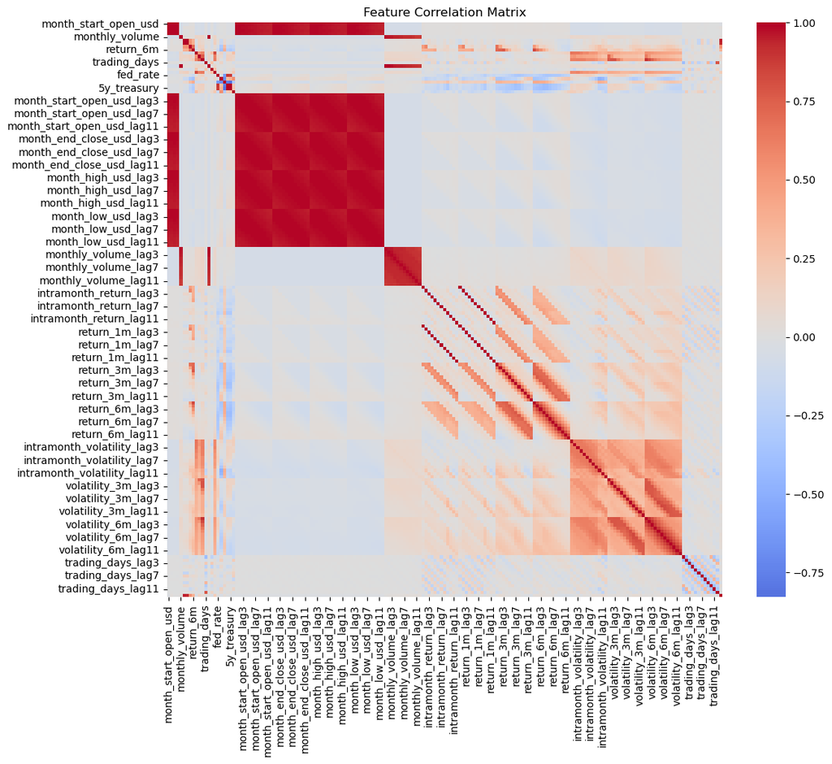

```python
import seaborn as sns
import matplotlib.pyplot as plt


correlation_features = numerical_features + ['excess_return']
corr = train[correlation_features].corr()

target_corr = corr['excess_return'].sort_values(ascending=False)
print("Top correlations with excess_return:")
print(target_corr.head(15))
print("\nLowest correlations with excess_return:")
print(target_corr.tail(15))

# Heatmap of all numeric features
plt.figure(figsize=(12,10))
sns.heatmap(corr, cmap="coolwarm", center=0)
plt.title("Feature Correlation Matrix")
plt.show()
```